# Gadiel_Shepherd_Project2_full_code_notebook

## Model Building

### Model Evaluation Criterion

- Defining a utlility function to collate evaluation metrics (accuracy, recall, precision and f1 score) into a single dataframe.

```python
def model_performance_classification(model,predictors,target):
  """
  To plot evaluation metrics.

  model: Model to evaluate
  predictors: Independent variables
  target: Dependent variable
  """
  # Predicting using the IVs
  pred=model.predict(predictors)

  # Calculating different metrics
  acc=accuracy_score(target,pred)
  recall=recall_score(target,pred)
  precision=precision_score(target,pred)
  f1=f1_score(target,pred)

  # Creating a dataframe of the evaluation metrics
  df_perf=pd.DataFrame(
      {"Accuracy":acc,"Recall":recall,"Precision":precision,"F1":f1},
      index=[0]
  )
  return df_perf
```

- Defining a function to plot the confusion matrix

```python
def plot_confusion_matrix(model,predictors,target):
  """
  To plot confusion matrix with percentages.

  model: Model to evaluate
  predictors: Independent variables
  target: Dependent variable
  """
  # Predicting the target values
  y_pred=model.predict(predictors)

  # Creating a confusion matrix
  cm=confusion_matrix(target,y_pred)

  # Creating labels for each cell in the confusion matrix for both count and percentage
  labels=np.asarray(
      [
          ["{0:0.0f}".format(item)+"\n{0:.2%}".format(item/cm.flatten().sum()) for item in cm.flatten()]
      ]
  ).reshape(2,2)

  #Plotting the confusion matrix with labels
  plt.figure(figsize=(6,4))
  sns.heatmap(cm,annot=labels,fmt="")
  plt.ylabel("True label")
  plt.xlabel("Predicted label")
  plt.show()
```

### Model Building

```python
# Creating an instance of the decision tree model
dtree1=DecisionTreeClassifier(random_state=RS)

# Fitting the model on the training data
dtree1.fit(X_train,y_train)
```

```
DecisionTreeClassifier(random_state=42)
```

```python
# Evaluating the model on the test set vs the train test
dtree1_train_perf=model_performance_classification(dtree1,X_train,y_train)
dtree1_test_perf=model_performance_classification(dtree1,X_test,y_test)
print("Evaluation Metrics of Train Set \n", dtree1_train_perf)
print('-'*100)
print("Evaluation Metrics of Test Set \n", dtree1_test_perf)
```

```
Evaluation Metrics of Train Set
    Accuracy  Recall  Precision   F1
0       1.0     1.0        1.0  1.0
----------------------------------------------------------------------------------------------------
Evaluation Metrics of Test Set
    Accuracy    Recall  Precision    F1
0     0.982  0.947917      0.875  0.91
```

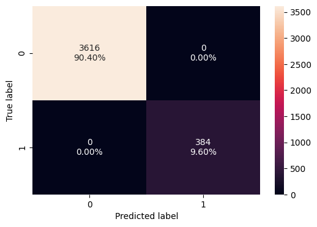

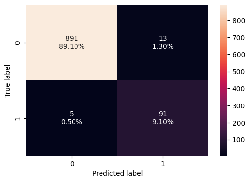

```
None None
```

```python
# Plotting the confusion matrix for train and test sets from the default model
print(plot_confusion_matrix(dtree1,X_train,y_train),plot_confusion_matrix(dtree1,X_test,y_test))
```

### Observations:

- The evaluation metrics on the train set is perfect, which is expected when fitting the default decision tree classifier to the train set.
  - This is due to the model maximizing purity/homogeniety of the leaf nodes.
  - This usually leads to overfitting and a worse perfomance on the test set.
- The evaluation metrics on the test set are surprsingly good (with a 98.2% accuracy, making only 18 mistakes(13 Type I + 5 Type II)), however this model is not fit for generalization.
  - The test set performed worst on Precision (0.875), which means that out of all the customers that were predicted to take out a loan, only 87.5% of them actually did take out a loan.
- It is clear that these metrics can be improved.

### Visualizing the Decsision Tree

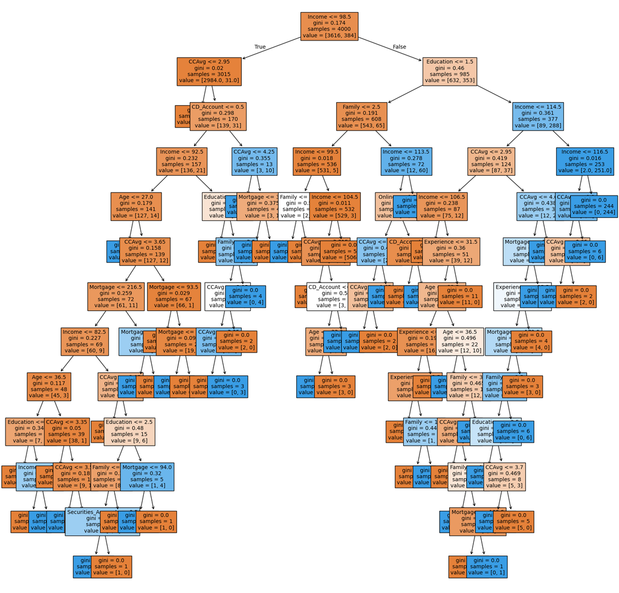

```
Tree depth: 12
Number of nodes: 127
Number of leaf nodes: 64
```

```python
# List of feature names in X_train
feature_names=list(X_train.columns)

# Plotting the decision tree
plt.figure(figsize=(20,20))
out=tree.plot_tree(dtree1,
                   feature_names=feature_names,
                   filled=True,
                   fontsize=10)
plt.show()

# Printing the the depth, number of nodes, and number of leaf nodes of the Decision Tree
depth_t1 = dtree1.get_depth()
n_nodes_t1 = dtree1.tree_.node_count
n_leaves_t1 = dtree1.get_n_leaves()

print(f"Tree depth: {depth_t1}")
print(f"Number of nodes: {n_nodes_t1}")
print(f"Number of leaf nodes: {n_leaves_t1}")
```

### Observations:

- The tree is extremely complex with 12 levels, 127 overall nodes and 64 leaf nodes.
- The default tree has grown to maximize purity/homogeniety of all the leaf nodes.
- The decision rule of the root node uses the Income attribute where the splitting criteria is Income <= 98.5.
  - If a customer meets the criteria, the splitting criteria of the child node is CCAvg <= 2.95.
  - If a customer does not meet the criteria, the splitting criteria of the child node is Education <= 1.5.
  - Subsequent internal nodes use attributes such as Income, CCAvg,CD_Account, Mortgage, Family, Age and Experience.

## Model Performance Improvement

Pre-Pruning:

- Let's try to improve the model using pre-pruning.
- This method bounds the hyperparameters to a predefined criteria and does not allow the tree to grow fully which would lead to overfitting.

```python
# Defining the parameters of the tree to iterate over
max_depth_values=np.arange(2,11,2)
max_leaf_nodes_values=np.arange(5,51,5)
min_samples_split_values=np.arange(5,51,5)

# Initialize variable to store the best model and its performance
best_estimator=None
best_score_diff=float('inf')

# Iterate over all combinations of the specified parameter values
for max_depth in max_depth_values:
  for max_leaf_nodes in max_leaf_nodes_values:
    for min_samples_split in min_samples_split_values:

      # Initialize the tree with the current set of parameters
      estimator=DecisionTreeClassifier(
          max_depth=max_depth,
          max_leaf_nodes=max_leaf_nodes,
          min_samples_split=min_samples_split,
          random_state=RS)
      # Fit the model to the training data
      estimator.fit(X_train,y_train)
      #Make predictions on the train and test sets
      y_train_pred=estimator.predict(X_train)
      y_test_pred=estimator.predict(X_test)
      # Calculate the F1 scores for the train and test sets
      train_f1_score=f1_score(y_train,y_train_pred)
      test_f1_score=f1_score(y_test,y_test_pred)
      # Calculate the absolute difference in F1 scores
      score_diff=abs(train_f1_score-test_f1_score)
      # Update the best estimator and best score if the current one has a smaller score difference
      if score_diff<best_score_diff:
        best_estimator=estimator
        best_score_diff=score_diff
# Best parameters
print("Best Estimator: ", best_estimator)
```

```
Best Estimator:  DecisionTreeClassifier(max_depth=np.int64(6), max_leaf_nodes=np.int64(25),
                       min_samples_split=np.int64(5), random_state=42)
```

- The best parameters are: max_depth=6, max_leaf_nodes=25, minimum_samples_split=5.

```python
# Creating an instance of the best model
dtree2=best_estimator

# Fitting the model on the training data
dtree2.fit(X_train,y_train)
```

```
DecisionTreeClassifier(max_depth=np.int64(6), max_leaf_nodes=np.int64(25),
                       min_samples_split=np.int64(5), random_state=42)
```

```python
# Evaluating the pre-pruned model on the test set vs the train test
dtree2_train_perf=model_performance_classification(dtree2,X_train,y_train)
dtree2_test_perf=model_performance_classification(dtree2,X_test,y_test)

print("Evaluation Metrics of Train Set \n", dtree2_train_perf)
print('-'*100)
print("Evaluation Metrics of Test Set \n", dtree2_test_perf)
```

```
Evaluation Metrics of Train Set
    Accuracy    Recall  Precision        F1
0   0.98825  0.908854   0.966759  0.936913
----------------------------------------------------------------------------------------------------
Evaluation Metrics of Test Set
    Accuracy    Recall  Precision       F1
0     0.987  0.958333   0.910891  0.93401
```

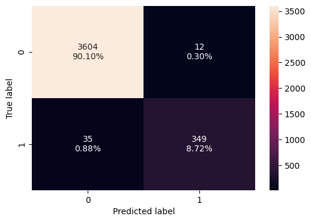

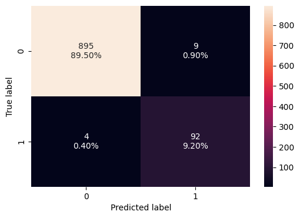

```
None None
```

```python
# Plotting the confusion matrix for train and test sets from the pre-pruned model
print(plot_confusion_matrix(dtree2,X_train,y_train),plot_confusion_matrix(dtree2,X_test,y_test))
```

### Observations:

- As expected, the evaluation metrics of the pre-pruned model on the train set is not perfect.
  - This is due to the pre-defined hyperparameters of the model which prevents the model from fully fitting to the train set. This prevents overfitting.
- We have successfully improved the evaluation metrics of the pre-pruned model on the test set when compared to the default model.
  - There is an improvement on all evaluation metrics, most notably on Precision (0.875 vs 0.911).
  - The pre-pruned model has made less mistakes (18 vs 13(9 Type I + 4 Type II)).
- In addition to this, the evaluation metrics of the test and train sets are very similar (especially in Accuracy and F1 Score).
  - This means that the generalization ability of the pre-pruned model is very good, which is an improvement in comparison to the default model. Therefore we have successfully prevented overfitting.
  - However it is important to note that the train and test sets have relatively different Recall and Precision scores.
    - The train set had a worse Recall score. In other words, out of all the customers who took out a loan, only 90.89% of them were predicted to take out a loan.
    - The test set had a worse Precision score. In other words, out of all the customers who were predicted to take out a loan, only 91.09% of them actually took out a loan.

### Visualizing the pre-pruned tree

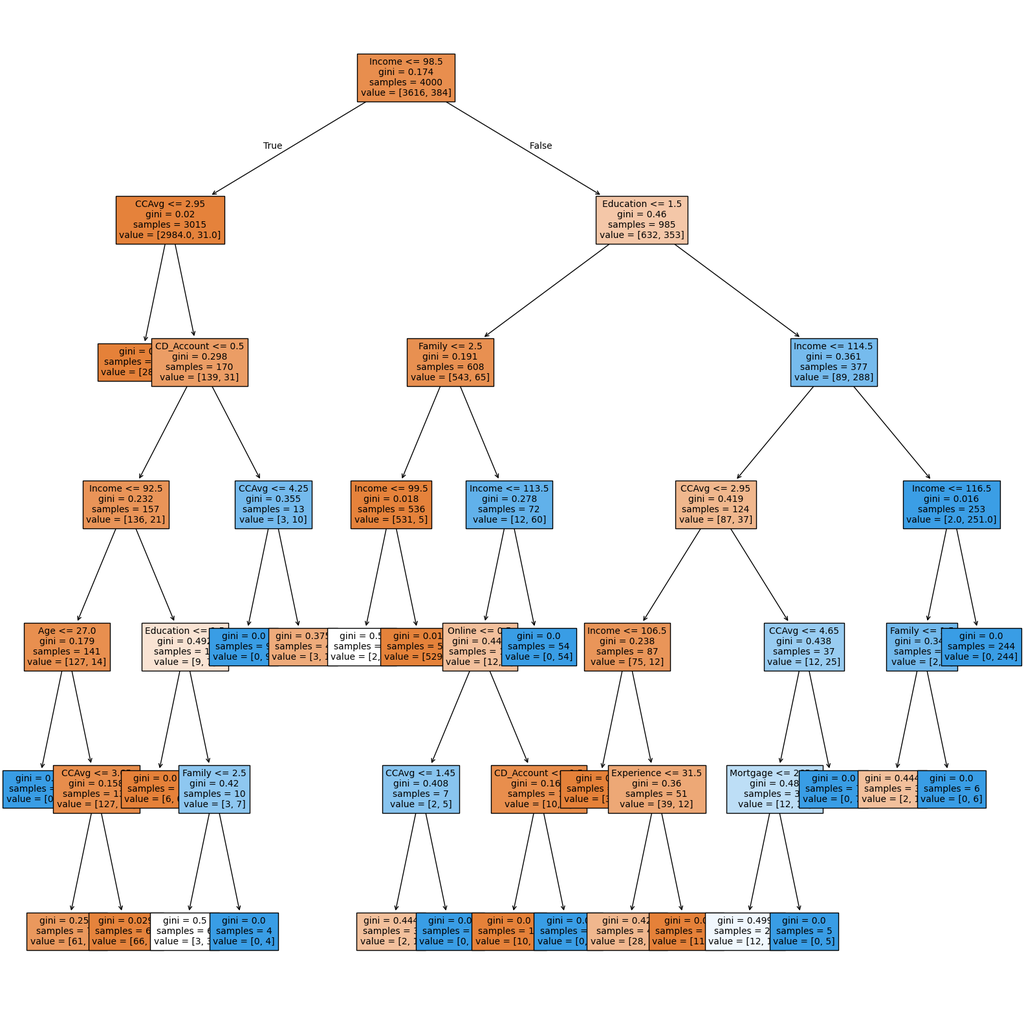

```
Tree depth: 6
Number of nodes: 49
Number of leaf nodes: 25
```

```python
# List of feature names in X_train
feature_names=list(X_train.columns)

# Plotting the decision tree
plt.figure(figsize=(20,20))
out=tree.plot_tree(dtree2,
                   feature_names=feature_names,
                   filled=True,
                   fontsize=10)
plt.show()

# Printing the the depth, number of nodes, and number of leaf nodes of the Decision Tree
depth_t2 = dtree2.get_depth()
n_nodes_t2 = dtree2.tree_.node_count
n_leaves_t2 = dtree2.get_n_leaves()

print(f"Tree depth: {depth_t2}")
print(f"Number of nodes: {n_nodes_t2}")
print(f"Number of leaf nodes: {n_leaves_t2}")
```

### Observations:

- The tree is less complex than the default tree.
  - It has a depth of 6, 49 overall nodes and 25 leaf nodes.
- It is a lot easier to visaully interpret the decision tree and its splitting criteria.
- The decision rule of the root node uses the Income attribute where the splitting criteria is Income <= 98.5.
  - If a customer meets the criteria, the splitting criteria of the child node is CCAvg <= 2.95.
  - If a customer does not meet the criteria, the splitting criteria of the child node is Education <= 1.5.
  - Subsequent nodes use attributes such as Income, CCAvg, CD_Account, Mortgage, Family, Age and Experience.